# Differential Expression

2017-09-27

```r
library(DESeq2)
library(bcbioRNASeq)

# Shared RMarkdown settings
prepareRNASeqTemplate()
if (file.exists("setup.R")) {
    source("setup.R")
}

# Load bcbioRNADataSet object
bcbName <- load(params$bcbFile)
bcb <- get(bcbName, inherits = FALSE)
if (!is(bcb, "bcbioRNADataSet")) {
    stop("bcb must bcbioRNADataSet class object")
}

# Design formula
# help("design", "DESeq2")
design <- params$design

# Contrast
# help("results", "DESeq2")
#   1. Design matrix parameter.
#   2. Numerator for LFC (expt).
#   3. Denominator for LFC (control).
contrast <- params$contrast

# Significance cutoffs
alpha <- params$alpha
lfc <- params$lfc

# Directory paths
outputDir <- params$outputDir
countsDir <- file.path(outputDir, "results", "counts")
deDir <- file.path(outputDir, "results", "differential_expression")
```

# Overview

```r
> dds <- DESeqDataSetFromTximport(txi = txi(bcb), colData = colData(bcb), design = design) %>%
+     DESeq
> rld <- rlog(dds)
```

# Alpha level (FDR) cutoffs

Let’s take a look at the number of genes we get with different false discovery rate (FDR) cutoffs. These tests subset *P* values that have been multiple test corrected using the Benjamini Hochberg (BH) method (Benjamini and Hochberg 1995).

```r
> alphaSummary(dds)
```

|  | 0.1 | 0.05 | 0.01 | 0.001 | 1e-06 |
| --- | --- | --- | --- | --- | --- |
| LFC > 0 (up) | 179, 0.61% | 142, 0.48% | 93, 0.32% | 58, 0.2% | 25, 0.085% |
| LFC < 0 (down) | 140, 0.48% | 104, 0.35% | 58, 0.2% | 38, 0.13% | 15, 0.051% |
| outliers | 0, 0% | 0, 0% | 0, 0% | 0, 0% | 0, 0% |
| low counts | 11599, 39% | 11046, 38% | 11046, 38% | 10494, 36% | 16570, 56% |
| cutoff | (mean count < 7) | (mean count < 6) | (mean count < 6) | (mean count < 5) | (mean count < 74) |

# Results

```r
> resUnshrunken <- results(
+     dds,
+     contrast = contrast,
+     alpha = alpha)
>
> # DESeqResults with shrunken log2 fold changes (LFC)
> # help("lfcShrink", "DESeq2")
> # Only `coef` or `contrast` can be specified, not both
> # Use the correct `coef` number to modify from `resultsNames(dds)`
> resShrunken <- lfcShrink(
+     dds = dds,
+     # coef = 2,
+     contrast = contrast,
+     res = resUnshrunken)
>
> # Use shrunken LFC values by default
> res <- resShrunken
```

We performed the analysis using a BH adjusted *P* value cutoff of 0.01 and a log fold-change (LFC) ratio cutoff of 0.

# Plots

## Mean average (MA)

An MA plot compares transformed counts on `M` (log ratio) and `A` (mean average) scales (Y. H. Yang et al. 2002).

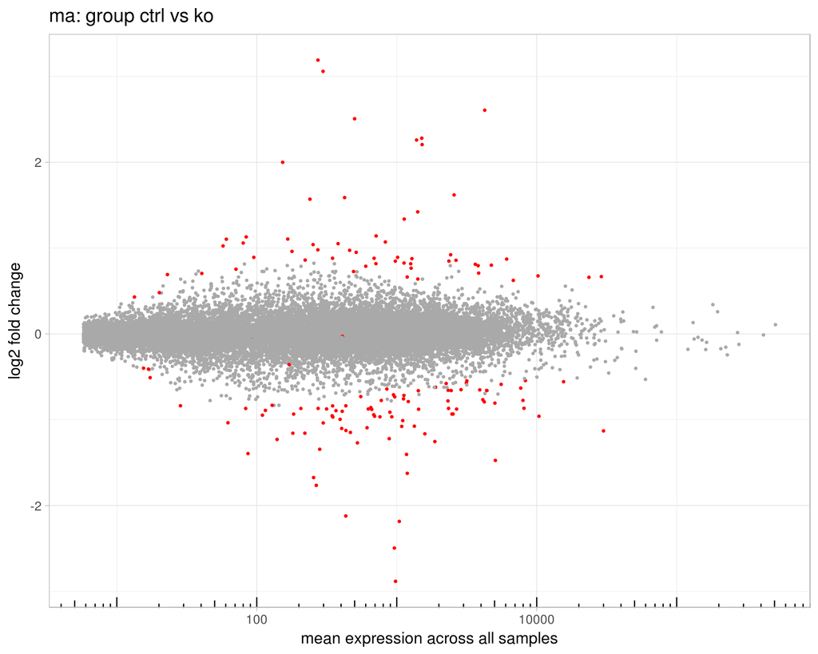

```r
> plotMA(res)
```

## Volcano

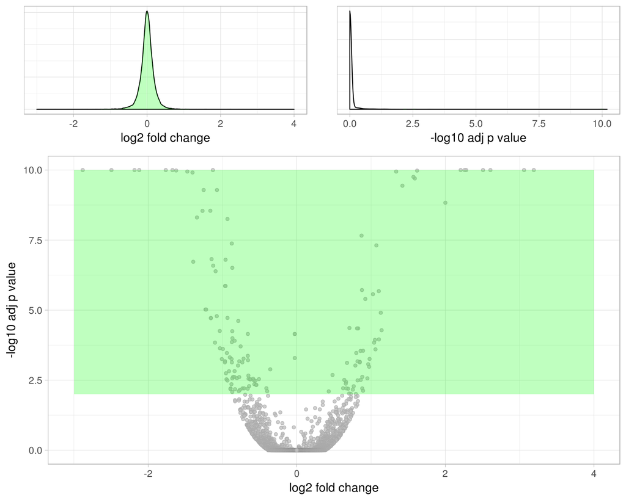

```r
> plotVolcano(res, lfc = lfc)
```

## Heatmap

This plot shows only differentially expressed genes on a per-sample basis. We have scaled the data by row and used the `ward.D2` method for clustering (Ward Jr 1963).

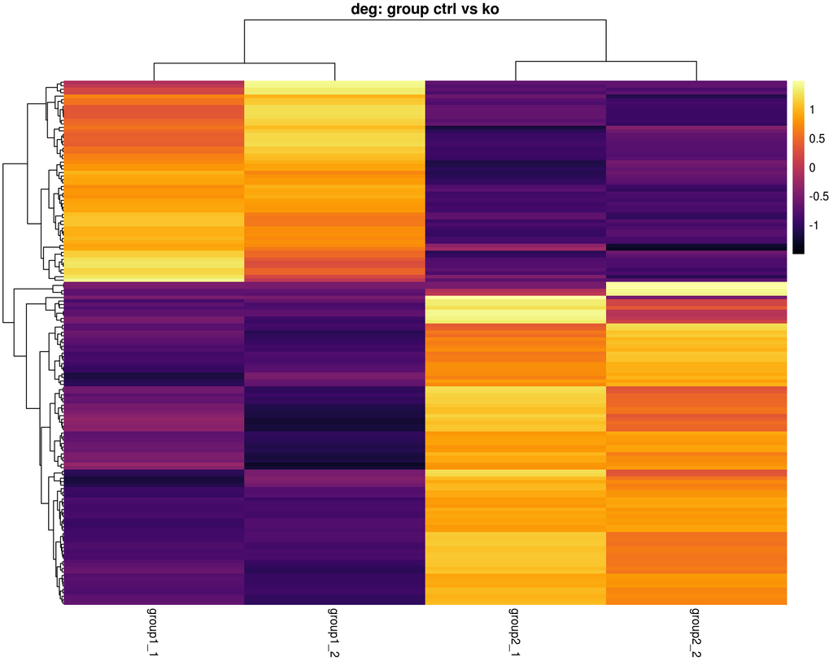

```r
> plotDEGHeatmap(res, counts = rld)
```

# File downloads

The results are saved as gzip-compressed comma separated values (CSV). Gzip compression is natively supported on [macOS](https://www.apple.com/macos) and Linux-based operating systems. If you’re running Windows, we recommend installing [7-Zip](http://www.7-zip.org). CSV files can be opened in [Excel](https://products.office.com/en-us/excel) or [RStudio](https://www.rstudio.com).

## Count matrices

- `normalizedCounts.csv.gz`: Use to evaluate individual genes and/or generate plots. These counts are normalized for the variation in sequencing depth across samples.
- `tpm.csv.gz`: Transcripts per million, scaled by length and also suitable for plotting.
- `rawCounts.csv.gz`: Only use to perform a new differential expression analysis. These counts will vary across samples due to differences in sequencing depth, and have not been normalized. Do not use this file for plotting genes.

## Differentially expressed genes (DEG)

```r
> resTbl <- resultsTables(res, lfc = lfc, dir = deDir)
```

DEG tables are sorted by BH-adjusted P value, and contain the following columns:

- `ensgene`: [Ensembl](http://useast.ensembl.org) gene identifier.
- `baseMean`: Mean of the normalized counts per gene for all samples.
- `log2FoldChange`: log2 fold change.
- `lfcSE`: log2 standard error.
- `stat`: Wald statistic.
- `pvalue`: Walt test *P* value.
- `padj`: BH adjusted Wald test *P* value (corrected for multiple comparisons; aka FDR).
- `externalGeneName`: [Ensembl](http://useast.ensembl.org) name (a.k.a. symbol).
- `description`: [Ensembl](http://useast.ensembl.org) description.
- `geneBiotype`: [Ensembl](http://useast.ensembl.org) biotype (e.g. `protein_coding`).

# Top tables

```r
> topTables(resTbl)
```

group ctrl vs ko (upregulated)

| ensgene | baseMean | lfc | padj | symbol | description |
| --- | --- | --- | --- | --- | --- |
| ENSMUSG00000052974 | 4250 | 2.607 | 2.38e-48 | Cyp2f2 | cytochrome P450, family 2, subfamily f, polypeptide 2 |
| ENSMUSG00000059824 | 1509 | 2.281 | 9.62e-46 | Dbp | D site albumin promoter binding protein |
| ENSMUSG00000066258 | 298 | 3.059 | 2.06e-40 | Trim12a | tripartite motif-containing 12A |
| ENSMUSG00000028358 | 500 | 2.507 | 1.29e-38 | Zfp618 | zinc finger protein 618 |
| ENSMUSG00000057596 | 274 | 3.190 | 1.29e-38 | Trim30d | tripartite motif-containing 30D |
| ENSMUSG00000021775 | 1518 | 2.206 | 2.31e-36 | Nr1d2 | nuclear receptor subfamily 1, group D, member 2 |
| ENSMUSG00000020889 | 1385 | 2.259 | 1.56e-25 | Nr1d1 | nuclear receptor subfamily 1, group D, member 1 |
| ENSMUSG00000032281 | 2568 | 1.620 | 4.72e-12 | Acsbg1 | acyl-CoA synthetase bubblegum family member 1 |
| ENSMUSG00000049892 | 1131 | 1.338 | 1.28e-11 | Rasd1 | RAS, dexamethasone-induced 1 |
| ENSMUSG00000040896 | 240 | 1.570 | 7.56e-11 | Kcnd3 | potassium voltage-gated channel, Shal-related family, member 3 |
| ENSMUSG00000001864 | 424 | 1.589 | 9.97e-11 | Aif1l | allograft inflammatory factor 1-like |
| ENSMUSG00000017969 | 1412 | 1.422 | 2.62e-10 | Ptgis | prostaglandin I2 (prostacyclin) synthase |
| ENSMUSG00000045868 | 153 | 2.000 | 1.37e-09 | Gvin1 | GTPase, very large interferon inducible 1 |
| ENSMUSG00000036856 | 6100 | 0.872 | 2.18e-08 | Wnt4 | wingless-type MMTV integration site family, member 4 |
| ENSMUSG00000035357 | 829 | 1.071 | 4.89e-08 | Pdzrn3 | PDZ domain containing RING finger 3 |
| ENSMUSG00000036502 | 1283 | 0.877 | 1.92e-06 | Tmem255a | transmembrane protein 255A |
| ENSMUSG00000029306 | 61 | 1.104 | 2.10e-06 | Ibsp | integrin binding sialoprotein |
| ENSMUSG00000096972 | 57 | 1.025 | 2.70e-06 | Gm26883 | predicted gene, 26883 |
| ENSMUSG00000069094 | 2428 | 0.922 | 4.00e-06 | Pde7a | phosphodiesterase 7A |
| ENSMUSG00000007682 | 84 | 1.130 | 1.24e-05 | Dio2 | deiodinase, iodothyronine, type II |
| ENSMUSG00000022419 | 3848 | 0.709 | 4.34e-05 | Deptor | DEP domain containing MTOR-interacting protein |
| ENSMUSG00000024360 | 3640 | 0.812 | 4.50e-05 | Etf1 | eukaryotic translation termination factor 1 |
| ENSMUSG00000031376 | 1127 | 0.826 | 4.50e-05 | Atp2b3 | ATPase, Ca++ transporting, plasma membrane 3 |
| ENSMUSG00000035686 | 712 | 1.142 | 5.22e-05 | Thrsp | thyroid hormone responsive |
| ENSMUSG00000030256 | 166 | 1.105 | 1.11e-04 | Bhlhe41 | basic helix-loop-helix family, member e41 |
| ENSMUSG00000002633 | 381 | 1.052 | 1.15e-04 | Shh | sonic hedgehog |
| ENSMUSG00000001665 | 252 | 1.041 | 1.45e-04 | Gstt3 | glutathione S-transferase, theta 3 |
| ENSMUSG00000060441 | 80 | 1.059 | 2.52e-04 | Trim5 | tripartite motif-containing 5 |
| ENSMUSG00000027227 | 1014 | 0.892 | 2.83e-04 | Sord | sorbitol dehydrogenase |
| ENSMUSG00000031824 | 2650 | 0.858 | 2.87e-04 | 6430548M08Rik | RIKEN cDNA 6430548M08 gene |
| ENSMUSG00000031451 | 4742 | 0.801 | 3.38e-04 | Gas6 | growth arrest specific 6 |
| ENSMUSG00000026527 | 273 | 0.980 | 5.53e-04 | Rgs7 | regulator of G protein signaling 7 |
| ENSMUSG00000025511 | 1258 | 0.818 | 6.73e-04 | Tspan4 | tetraspanin 4 |
| ENSMUSG00000023019 | 2359 | 0.849 | 7.00e-04 | Gpd1 | glycerol-3-phosphate dehydrogenase 1 (soluble) |
| ENSMUSG00000002324 | 976 | 0.848 | 7.32e-04 | Rec8 | REC8 meiotic recombination protein |
| ENSMUSG00000038393 | 10215 | 0.676 | 7.63e-04 | Txnip | thioredoxin interacting protein |
| ENSMUSG00000027875 | 179 | 0.962 | 8.53e-04 | Hmgcs2 | 3-hydroxy-3-methylglutaryl-Coenzyme A synthase 2 |
| ENSMUSG00000055368 | 600 | 0.789 | 9.49e-04 | Slc6a2 | solute carrier family 6 (neurotransmitter transporter, noradrenalin), member 2 |
| ENSMUSG00000002289 | 461 | 0.974 | 1.05e-03 | Angptl4 | angiopoietin-like 4 |
| ENSMUSG00000066068 | 20 | 0.481 | 2.07e-03 | Gm13611 | predicted gene 13611 |
| ENSMUSG00000016386 | 348 | 0.882 | 2.41e-03 | Mpped2 | metallophosphoesterase domain containing 2 |
| ENSMUSG00000035211 | 513 | 0.950 | 2.72e-03 | Xrra1 | X-ray radiation resistance associated 1 |
| ENSMUSG00000024731 | 222 | 0.861 | 3.10e-03 | Ms4a10 | membrane-spanning 4-domains, subfamily A, member 10 |
| ENSMUSG00000051855 | 1415 | 0.640 | 3.10e-03 | Mest | mesoderm specific transcript |
| ENSMUSG00000007097 | 710 | 0.819 | 3.22e-03 | Atp1a2 | ATPase, Na+/K+ transporting, alpha 2 polypeptide |
| ENSMUSG00000031217 | 1188 | 0.663 | 3.67e-03 | Efnb1 | ephrin B1 |
| ENSMUSG00000049265 | 23606 | 0.660 | 4.22e-03 | Kcnk3 | potassium channel, subfamily K, member 3 |
| ENSMUSG00000026678 | 1266 | 0.766 | 5.23e-03 | Rgs5 | regulator of G-protein signaling 5 |
| ENSMUSG00000005268 | 6801 | 0.624 | 6.16e-03 | Prlr | prolactin receptor |
| ENSMUSG00000024164 | 28947 | 0.668 | 6.23e-03 | C3 | complement component 3 |

group ctrl vs ko (downregulated)

| ensgene | baseMean | lfc | padj | symbol | description |
| --- | --- | --- | --- | --- | --- |
| ENSMUSG00000020038 | 962 | -2.4946 | 4.37e-51 | Cry1 | cryptochrome 1 (photolyase-like) |
| ENSMUSG00000026442 | 980 | -2.8816 | 8.45e-40 | Nfasc | neurofascin |
| ENSMUSG00000026077 | 1043 | -2.1837 | 5.01e-25 | Npas2 | neuronal PAS domain protein 2 |
| ENSMUSG00000029757 | 432 | -2.1206 | 1.40e-21 | Dync1i1 | dynein cytoplasmic 1 intermediate chain 1 |
| ENSMUSG00000027712 | 30000 | -1.1295 | 8.95e-15 | Anxa5 | annexin A5 |
| ENSMUSG00000029108 | 266 | -1.7638 | 9.39e-15 | Pcdh7 | protocadherin 7 |
| ENSMUSG00000102802 | 255 | -1.6730 | 1.95e-13 | Mgam2-ps | maltase-glucoamylase 2, pseudogene |
| ENSMUSG00000022790 | 1189 | -1.6237 | 3.57e-12 | Igsf11 | immunoglobulin superfamily, member 11 |
| ENSMUSG00000053279 | 5065 | -1.4735 | 1.26e-11 | Aldh1a1 | aldehyde dehydrogenase family 1, subfamily A1 |
| ENSMUSG00000023959 | 1175 | -1.4036 | 2.22e-11 | Clic5 | chloride intracellular channel 5 |
| ENSMUSG00000028150 | 1336 | -1.0744 | 4.15e-10 | Rorc | RAR-related orphan receptor gamma |
| ENSMUSG00000050447 | 1872 | -1.2537 | 4.15e-10 | Lypd6 | LY6/PLAUR domain containing 6 |
| ENSMUSG00000051359 | 1588 | -1.1634 | 2.73e-09 | Ncald | neurocalcin delta |
| ENSMUSG00000060044 | 523 | -1.2689 | 2.76e-09 | Tmem26 | transmembrane protein 26 |
| ENSMUSG00000062760 | 282 | -1.3436 | 4.84e-09 | 1810041L15Rik | RIKEN cDNA 1810041L15 gene |
| ENSMUSG00000028214 | 2525 | -0.9329 | 5.48e-09 | Gem | GTP binding protein (gene overexpressed in skeletal muscle) |
| ENSMUSG00000004035 | 2676 | -0.8753 | 4.17e-08 | Gstm7 | glutathione S-transferase, mu 7 |
| ENSMUSG00000027335 | 467 | -1.1473 | 1.51e-07 | Adra1d | adrenergic receptor, alpha 1d |
| ENSMUSG00000004098 | 10375 | -0.9591 | 1.59e-07 | Col5a3 | collagen, type V, alpha 3 |
| ENSMUSG00000045094 | 87 | -1.3938 | 1.88e-07 | Arhgef37 | Rho guanine nucleotide exchange factor (GEF) 37 |
| ENSMUSG00000037946 | 434 | -1.1248 | 2.58e-07 | Fgd3 | FYVE, RhoGEF and PH domain containing 3 |
| ENSMUSG00000030630 | 2345 | -0.8676 | 3.09e-07 | Fah | fumarylacetoacetate hydrolase |
| ENSMUSG00000039208 | 613 | -1.0928 | 4.09e-07 | Metrnl | meteorin, glial cell differentiation regulator-like |
| ENSMUSG00000023067 | 695 | -0.9593 | 1.37e-06 | Cdkn1a | cyclin-dependent kinase inhibitor 1A (P21) |
| ENSMUSG00000056749 | 922 | -0.9653 | 1.37e-06 | Nfil3 | nuclear factor, interleukin 3, regulated |
| ENSMUSG00000037705 | 140 | -1.2291 | 9.51e-06 | Tecta | tectorin alpha |
| ENSMUSG00000063659 | 883 | -1.2201 | 9.51e-06 | Zbtb18 | zinc finger and BTB domain containing 18 |
| ENSMUSG00000028179 | 1086 | -1.0770 | 1.64e-05 | Cth | cystathionase (cystathionine gamma-lyase) |
| ENSMUSG00000031380 | 2479 | -0.9329 | 1.90e-05 | Vegfd | vascular endothelial growth factor D |
| ENSMUSG00000055305 | 221 | -1.1564 | 1.90e-05 | Zfp93 | zinc finger protein 93 |
| ENSMUSG00000028359 | 181 | -1.1568 | 1.95e-05 | Orm3 | orosomucoid 3 |
| ENSMUSG00000022500 | 1209 | -0.7874 | 2.44e-05 | Litaf | LPS-induced TN factor |
| ENSMUSG00000031543 | 298 | -1.0367 | 5.54e-05 | Ank1 | ankyrin 1, erythroid |
| ENSMUSG00000035270 | 83 | -0.8682 | 5.64e-05 | Impg2 | interphotoreceptor matrix proteoglycan 2 |
| ENSMUSG00000034158 | 4388 | -0.6586 | 7.07e-05 | Lrrc58 | leucine rich repeat containing 58 |
| ENSMUSG00000083833 | 409 | -0.0277 | 7.11e-05 | Gm13841 | predicted gene 13841 |
| ENSMUSG00000094497 | 409 | -0.0277 | 7.11e-05 | Gm8210 | predicted pseudogene 8210 |
| ENSMUSG00000028760 | 8111 | -0.8661 | 1.01e-04 | Eif4g3 | eukaryotic translation initiation factor 4 gamma, 3 |
| ENSMUSG00000030735 | 28 | -0.8366 | 1.24e-04 | Gm9755 | predicted pseudogene 9755 |
| ENSMUSG00000000628 | 626 | -0.8743 | 1.38e-04 | Hk2 | hexokinase 2 |
| ENSMUSG00000036545 | 404 | -1.1009 | 1.45e-04 | Adamts2 | a disintegrin-like and metallopeptidase (reprolysin type) with thrombospondin type 1 motif, 2 |
| ENSMUSG00000030583 | 1117 | -0.7560 | 1.97e-04 | Sipa1l3 | signal-induced proliferation-associated 1 like 3 |
| ENSMUSG00000097836 | 62 | -1.0347 | 2.29e-04 | Gm26903 | predicted gene, 26903 |
| ENSMUSG00000099009 | 394 | -0.9948 | 2.43e-04 | Rdh16f1 | RDH16 family member 1 |
| ENSMUSG00000052852 | 685 | -0.9412 | 3.39e-04 | Reep1 | receptor accessory protein 1 |
| ENSMUSG00000006611 | 2447 | -0.6594 | 4.28e-04 | Hfe | hemochromatosis |
| ENSMUSG00000001334 | 408 | -0.9014 | 4.85e-04 | Fndc5 | fibronectin type III domain containing 5 |
| ENSMUSG00000055298 | 92 | -0.0277 | 5.13e-04 | Ctsj | cathepsin J |
| ENSMUSG00000029385 | 1125 | -0.7160 | 5.41e-04 | Ccng2 | cyclin G2 |
| ENSMUSG00000025321 | 1104 | -1.0093 | 5.58e-04 | Itgb8 | integrin beta 8 |

# Methods

RNA-seq counts were generated by [bcbio](https://github.com/chapmanb/bcbio-nextgen) and bcbioRNASeq using salmon (Patro et al. 2017). Counts were imported into [R](https://www.r-project.org) using [tximport](https://bioconductor.org/packages/release/bioc/html/tximport.html) (Soneson, Love, and Robinson 2015) and [DESeq2](https://bioconductor.org/packages/release/bioc/html/DESeq2.html) (Love, Huber, and Anders 2014). Gene annotations were obtained from [Ensembl](http://useast.ensembl.org). Plots were generated by [ggplot2](http://ggplot2.org) (Wickham 2009). Heatmaps were generated by [pheatmap](https://cran.r-project.org/web/packages/pheatmap/index.html) (Kolde 2015).

```r
> # Print YAML parameters, if set
> if (exists("params") & is(params, "knit_param_list")) {
+     print(params)
+ }
```

Benjamini, Yoav, and Yosef Hochberg. 1995. “Controlling the False Discovery Rate: A Practical and Powerful Approach to Multiple Testing.” *Journal of the Royal Statistical Society. Series B (Methodological)* 57 (1): 289–300.

Cui, Xiangqin, and Gary A Churchill. 2003. “Statistical tests for differential expression in cDNA microarray experiments.” 4 (4): 210.

Kolde, Raivo. 2015. *pheatmap: Pretty Heatmaps*.

Li, Wentian, Jan Freudenberg, Young Ju Suh, and Yaning Yang. 2014. “Using volcano plots and regularized-chi statistics in genetic association studies.” *Computational Biology and Chemistry* 48 (February): 77–83.

Love, Michael I, Wolfgang Huber, and Simon Anders. 2014. “Moderated estimation of fold change and dispersion for RNA-seq data with DESeq2.” 15 (12): 550.

Patro, Rob, Geet Duggal, Michael I Love, Rafael A Irizarry, and Carl Kingsford. 2017. “Salmon provides fast and bias-aware quantification of transcript expression.” *Nature Methods* 31 (4): 3881–3419.

Soneson, Charlotte, Michael I Love, and Mark D Robinson. 2015. “Differential analyses for RNA-seq: transcript-level estimates improve gene-level inferences.” *F1000Research* 4: 1521.

Ward Jr, Joe H. 1963. “Hierarchical Grouping to Optimize an Objective Function.” *Journal of the American Statistical Association* 58 (301): 236–44.

Wickham, Hadley. 2009. *ggplot2: Elegant Graphics for Data Analysis.* Springer New York.

Yang, Yee Hwa, Sandrine Dudoit, Percy Luu, David M Lin, Vivian Peng, John Ngai, and Terence P Speed. 2002. “Normalization for cDNA microarray data: a robust composite method addressing single and multiple slide systematic variation.” *Nucleic Acids Research* 30 (4): e15.